# Fairness

Magnus Nielsen, SODAS, UCPH

## Agenda

- What is fairness?
- Algorithmic decisions
- Auditing
- Statistical fairness measures
  - Independence
  - Separation
  - Sufficiency
- Achieving fairness

## Introduction

This session will be based mainly on the book [Fairness and Machine Learning: Limitations and Opportunities](https://fairmlbook.org/) (Barocas et al., 2019)

- Available online at fairmlbook.org
- Good starting point for discussing fairness
- Updated in 2022

A survey on more aspects and applications can be found in Mehrabi et al. (2021)

# What is fairness?

## Illuminate we will!

Ursula Franklin (Olteanu et al., 2019):

- *“For your own sanity, you have to remember that not all problems can be solved. Not all problems can be solved, but all problems can be illuminated”*

## Question

In your opinion, what is fairness in the context of machine learning? What is bias?

- Does it depend on the situation? Algorithm?

## Fairness is a societal concept

Chouldechova (2017):

- *“It is important to bear in mind that fairness itself (…) is a social and ethical concept, not a statistical concept.”*

Nevertheless, we’ll try to turn it into observable statistical measures towards the end

## But first, bias

Bias is a broad term with many different interpretations

Some people try to avoid this term due to the ambiguity, including Barocas et al. (2019)

## Some examples

The list is long

- Measurement bias
- Omitted variable bias
- Sampling bias
- Aggregation bias
- Self-selection bias

## Unfair, biased or both?

[figure not shown]

Gender stereotypes

<sub><sup>Source: Barocas et al. (2019)</sup></sub>

## Problem… solved?

[figure not shown]

Default gender

<sub><sup>Source: Google Translate</sup></sub>

## Problem solved!

[figure not shown]

Multiple options

<sub><sup>Source: Google Translate</sup></sub>

## Algorithmic fairness

Algorithmic fairness is a relatively new concept

- Fairness as a concept has existed for a long time
- Algorithms have existed for a long time

Lots of information on fairness, but generally not with respect to algorithms

## Fairness & decision-making

An *‘absence of any prejudice or favoritism toward an individual or group based on their inherent or acquired characteristics’* (Mehrabi et al., 2021)

We will consider group fairness

- No discrimination based on sensitive attributes such as race, gender, ethnicity

For a more thorough walkthrough of moral notions of fairness, see [chapter 4 in Barocas et al., 2019](https://fairmlbook.org/relative.html)

## Unfairness?

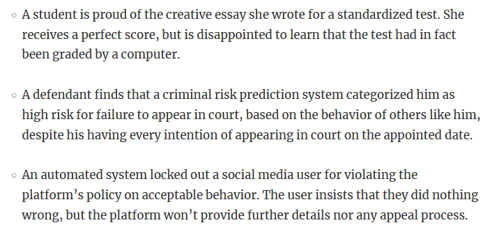

Example situations

<sub><sup>Source: Barocas et al. (2019)</sup></sub>

## Legitimacy

Is it right to deploy a machine learning algorithm in the first place?

- This we call legitimacy

Precedes other fairness concerns

- No algorithm $\rightarrow$ no algorithmic fairness concerns

# Algorithmic decisions

## What are algorithms replacing?

Humans are subject to subjectivity, arbitrariness, and inconsistency

- Historically replaced by bureaucracies

Algorithms most commonly replace bureaucracies

- Seldom are important decisions in settings of social-scientific importance made by a single human

## Legitimacy

Public institutions are in general more regulated than private companies

- Higher need for legitimacy

To increase legitimacy, consider things such as

- Transparency
- Relevance of inputs
- Possibility for recourse

## Three situations

Automating pre-existing decision-making rules

- Hardcoding, not machine learning

Learning decision-making rules from data on past decisions in order to automate them

- Target is given by previous decisions

Deriving decision-making rules by learning to predict a target

- New target to be decided upon

## Question

You’re tasked with creating a new centralized admissions system for higher education using machine learning.

- What is your target of choice?
- Does it depend on your employer?

## Fixed decision-makers

Algorithmic decisions as a process of inductive reasoning

- Choice of target important

Some issues to consider:

- Overfitting
  - We have tools to combat this
- Distribution shifts
  - Hot topic in research

# Auditing

## Examining decision-makers

Given a

- notion of fairness
- decision-maker (black box)

We can audit the decision-maker!

## Classic auditing

Ayres & Siegelman (1995)

- Send ‘identical’ testers to bargain for cars
- Vary race
- Black males receive final offers that are $1.100 more than white males

Bertrand & Mullainathan (2004)

- Send identical job applications to apply for jobs
- Vary name
- Traditionally white names 50% more likely to receive callbacks

## Question

What could be reasons that firms engage in this sort of discrimination?

- Is it fair?

## Fairness as blindness

A wish for null findings implicate no discrimination based on sensitive attribute

- Based on both observables (somewhat) and unobservables
- This subsumes a definition of fairness as blindness

Possible to illuminate decision making with partial dependence functions

# Statistical fairness measures

## Binary classification

We have

- Observed set of target and features, $\{Y, X\}$
- $X$ contains a sensitive attribute $A$
- A risk score generated by a classifier

$$r(x)=P\{Y=1∣X=x\}$$

Based on this risk score, we can calculate a predicted outcome $Y$

## Question

Can we obtain fairness by withholding information about sensitive attributes?

## No fairness through unawareness

[figure not shown]

Multiple correlated variables captures bias

<sub><sup>Source: Barocas et al. (2019)</sup></sub>

## Different types of fairness

Fundamentally three types of fairness metrics

- Acceptance rates, $P\{\widehat Y=1\}$
- Error rates, $P\{\widehat Y=0∣Y=1\}$ and $P\{\widehat Y=1∣Y=0\}$
- Outcome frequency given risk score, $P\{Y=1∣R=r\}$

These are equalized across groups defined by the sensitive attribute

## Loan applications

We will consider the same example for our fairness metrics

Given

- Information on gender ($A$), income (and other things) ($X$) and outcome ($Y$)

Decision to make: Who should get a loan?

Question: What target should we use to create our model?

# Independence

## Acceptance rate parity

‘True’ equality

- Sensitive attribute is unconditionally independent of score
- $A \perp R$
- Equal acceptance across groups

This is also commonly referred to as demographic parity

## Rewriting

Easy to work with algorithmically

$$P\{\widehat Y | A = a\} = P\{\widehat Y | A = b\}$$

In practice:

- Calculate mean of $\widehat Y$ across sensitive attribute values
- Assert if they differ

## Question

Could independence have adverse consequences for either group in the loans context?

- Consider the qualifications of the applicants
- How could one achieve independence?

## Relaxations

$$P\{\widehat Y | A = a\} \geq P\{\widehat Y | A = b\} - \epsilon$$

$$\frac{P\{\widehat Y | A = a\}}{P\{\widehat Y | A = b\}} \geq 1 - \epsilon$$

The U.S. has an [80% rule to detect discriminatory hiring](https://www.jfmeltonlaw.com/articles/understanding-the-80-rule/)

- Protected groups hired at least 80% as much as white men
- Feldman et al. (2015) argue that $\epsilon = 0.2$ encapsulates this
- *‘Supreme Court has resisted a “rigid mathematical formula”’* (Feldman et al., 2015)

## Some considerations

No influence if groups differ in covariates and outcomes

- Normative question if desired

Can lead to adverse outcomes, e.g.

- Increase in acceptance for minority group
- Can create more false positives
- Creates bad track record

Note that minority groups by definition have less training data

## Question

Assume that men overall are worse at paying back loans and defaulting is costly

- Just assumptions
- No assumptions as to why

Could this justify some discrimination based on gender?

# Separation

## Error rate parity

Equality within error rates

- Score independent of sensitive attribute given outcome
- $R \perp A | Y$
- Equalization of errors made within each strata defined by true outcome

Also known as equalized odds

## Rewriting for binary classifier

$$P \{\widehat Y = 1 | Y = 1, A = a\} = P \{\widehat Y = 1 | Y = 1, A = b\}$$

$$P \{\widehat Y = 1 | Y = 0, A = a\} = P \{\widehat Y = 1 | Y = 0, A = b\}$$

Equality of

- False negative rate
  - Thereby also true positive rate
- False positive rate
  - Thereby also true negative rate

## Why?

Generally misclassification has a cost, e.g. a lost opportunity

- Higher error rates amongst disadvantaged groups cause further harm

Note that target variables can encode previous inequality and injustice

- Separation doesn’t create fairness, but this is more general to supervised learning as a whole

## Question

What are the implications of separation for our loan model?

- Is this fair?

## Visually

[figure not shown]

Achievable false and true positive rates

<sub><sup>Source: Barocas et al. (2019)</sup></sub>

## Achieving separation

Tools to achieve red area in figure achievable by a combination of

- Linear combinations of the classifier and classifiers that always predict either true or false
- Different thresholds

## Relaxations

Equality of either false negative rate or false positive rate

Consider the costs of misclassification and who experiences them

An example: Screening for job interviews

- Cost to applicant if false negative (denied opportunity)
- Cost to firm if false positive (wasted time)
- Perhaps equality of false negative rates most important

## Question

Do you believe a relaxation is appropriate in the loan example?

# Sufficiency

## Calibrated risk scores

Given a risk score, groups should not differ in outcomes

- Outcome independent of sensitive attribute given risk score
- $Y \perp A | R$

If a model predicts a high risk, then it should be the same high risk for both groups

- No additional information in the sensitive variable

## Rewriting

$$P\{Y = 1 ∣ R = r, A = a \} = P\{Y = 1 ∣ R = r, A = b \}$$

A flexible model which uses $A$ as an input generally (approximately) achieves this

- If the sensitive attribute has predictive power, the model utilizes this information

Fairness through awareness

- In contrast to fairness through unawareness

## Question

What are the implications of sufficiency for our loan model?

- Is this fair?

# Incompatibilities

## A choice to make

We are generally not able to satisfy all fairness criteria at once!

- Trade-offs
- We must consider what is appropriate in our case

The proofs for the following three incompatibilities are found in Barocas et al. (2019)

## Independence and sufficiency

Assume $A \not\perp Y$

- Different rates of positive outcomes

Then independence and sufficiency cannot both hold

- Sufficiency requires that the additional information from $A$ encoded in risk score, but independence requires that score and sensitive attribute are uncorrelated

## Independence and separation

Assume $Y$ binary, $A \not\perp Y$ and $R \not\perp Y$

- Different rates of positive outcomes and risk score has predictive power

Then independence and separation cannot both hold

- Independence requires that risk score independent of sensitive attribute, but this causes unequal error rates when baselines differ

## Separation and sufficiency

Assume $A \not\perp Y$ and all events in the joint distribution $(R, A, Y)$ has positive density

- Different rates of positive outcomes and risk score never fully resolves uncertainty

Then separation and sufficiency cannot both hold

- Sufficiency requires that information about sensitive attribute encoded in score, but then different error rates occur

# Achieving fairness

## Timing

When in the process to achieve fairness

- Pre-processing, e.g. removing information about sensitive attributes
- In-processing, e.g. constraints based on fairness
- Post-processing, e.g. combining with other classifiers

Doing only fairness assessment and no mitigation is common

## Post-processing

Post-processing is common

- Relies explicitly on group membership
- Will be examined in exercises

Comes with some (near) optimality guarantees

## Observational criteria

We’ve now looked at different criteria of fairness based on observables

- Many more exist, see table in bottom of ‘Classification’ in Barocas et al. (2019)

Note that this doesn’t tell us anything about mechanisms or causes

- Is it the decision-maker?
- Society as a whole?

## How to learn about mechanisms

Attempts with causality

- SCM’s: Causal discovery is not easy in the social sciences
- PO: You need a research design

## A reminder

Once again remember Chouldechova (2017):

- *“It is important to bear in mind that fairness itself (…) is a social and ethical concept, not a statistical concept.”*

# References

Ayres, I., & Siegelman, P. (1995). Race and gender discrimination in bargaining for a new car. The American Economic Review, 304-321.

Barocas, S., Hardt, M., & Narayanan, A. (2019). Fairness and Machine Learning: Limitations and Opportunities. fairmlbook.org.

Bertrand, M., & Mullainathan, S. (2004). Are Emily and Greg more employable than Lakisha and Jamal? A field experiment on labor market discrimination. American economic review, 94(4), 991-1013.

Chouldechova, A. (2017). Fair prediction with disparate impact: A study of bias in recidivism prediction instruments. Big data, 5(2), 153-163.

Feldman, M., Friedler, S. A., Moeller, J., Scheidegger, C., & Venkatasubramanian, S. (2015, August). Certifying and removing disparate impact. In proceedings of the 21th ACM SIGKDD international conference on knowledge discovery and data mining (pp. 259-268).

Mehrabi, N., Morstatter, F., Saxena, N., Lerman, K., & Galstyan, A. (2021). A survey on bias and fairness in machine learning. ACM Computing Surveys (CSUR), 54(6), 1-35.

Olteanu, A., Castillo, C., Diaz, F., & Kıcıman, E. (2019). Social data: Biases, methodological pitfalls, and ethical boundaries. Frontiers in Big Data, 2, 13.